# Data Transformation

Wenjie Zhu, Yibai Liu, Jin Qian

11/18/2020

```r
library(readr)
library(tidyverse)
library(socviz)
```

## (1) Election voting results data transformation

```r
# (1) state level
# Data collected in 22 Nov
president2020 <- read.csv('Popular vote backend - Sheet1.csv') %>%
  filter(state %in% usmap::statepop$full)%>%
  select(stateid,state, dem_votes,rep_votes,dem_percent,rep_percent)
# make column `state` consistent & don't consider ("Maine 2nd District"    "Nebraska 2nd District" "Maine 1st District"  "Nebraska 1st District" "Nebraska 3rd District")

# Add a column: temporary result -> `tmp_result`
president2020 <- president2020 %>%
  mutate(tmp_result = ifelse(president2020$dem_percent>president2020$rep_percent,'Dem.','Rep.'))

# convert to categorical variables
qb_t = quantile(president2020$rep_percent,c(0,0.2,0.4,0.6,0.8,1.0))
qb_b = quantile(president2020$dem_percent,c(0,0.2,0.4,0.6,0.8,1.0))

president2020 <- president2020%>%
  mutate(Trump_cut =  cut(president2020$rep_percent,qb_t,labels = c("0-20%", "20-40%","40-60%","60-80%", "80-100%"),include.lowest = TRUE)) %>%
  mutate(Biden_cut =  cut(president2020$dem_percent,qb_b,labels = c("0-20%", "20-40%","40-60%","60-80%", "80-100%"),include.lowest = TRUE))


# (2) County Level
# County2020 <- read_csv('https://raw.githubusercontent.com/tonmcg/US_County_Level_Election_Results_08-20/master/2020_US_County_Level_Presidential_Results.csv')
County2020 <- read.csv("2020_US_County_Level_Presidential_Results.csv",
                       header = TRUE,fileEncoding="UTF-8-BOM",
                       colClasses=c("county_fips"="character"))

county_full <- right_join(socviz::county_map,County2020, by = c('id' = 'county_fips')) %>% as_tibble()

b1 <- c(min(county_full$diff))
b2 <- fivenum(county_full$diff[county_full$diff<0])[3]
b3 <- 0
b4 <- fivenum(county_full$diff[county_full$diff>0])[3]
b5 <- c(max(county_full$diff))

diff_l <- cut(county_full$diff, breaks = c(b1,b2,b3,b4,b5))


# (3) Time Level
elections_historic_new <- socviz::elections_historic
elections_historic_new$ec_pct[elections_historic_new$year == 2016] <- 304/(304+227)
elections_historic_new$popular_pct[elections_historic_new$year == 2016] <- 0.461
elections_historic_new$popular_margin[elections_historic_new$year == 2016] <- -0.021

elections_historic_full <- elections_historic_new
elections_historic_new <- elections_historic_new %>%
  select(c(win_party,popular_pct,ec_pct,winner_label))

# add data for 2020
data2020 <- data.frame(win_party = 'Dem.',popular_pct = 0.510,ec_pct = 306/(306+232), winner_label = 'Biden 2020')

elections_historic_new <- rbind(elections_historic_new,data2020)
```

## (2) Contribution receipts data transformation

```r
contributions1 <- read.csv("contribution_bind.csv",
                        header = TRUE,fileEncoding="UTF-8-BOM")

# Extract columns
DataDescription<- read.csv("DatasetDescription.csv",header = TRUE, fileEncoding="UTF-8-BOM")
columns <- as.vector(DataDescription[13:26,1])

contributions1<- contributions1 %>%
  select(columns[1:14])

# Change data types and factorize categorical variables
contributions1$committee_name <- as.factor(contributions1$committee_name)
contributions1$committee_name <- fct_recode(contributions1$committee_name,TRUMP = "DONALD J. TRUMP FOR PRESIDENT, INC.",BIDEN = "BIDEN FOR PRESIDENT")
contributions1$contribution_receipt_date <- as.Date(contributions1$contribution_receipt_date, format = "%m/%d/%y")

#filter contributor_state
state<- c("AL","AK","AZ","AR","CA","CO","CT","DE","DC","FL","GA","HI","ID","IL","IN","IA","KS","KY","LA","ME","MD","MA","MI","MN","MS","MO","MT","NE","NV", "NH", "NJ", "NM", "NY", "NC", "ND", "OH", "OK", "OR", "PA", "RI", "SC", "SD", "TN", "TX", "UT", "VT", "VA", "WA", "WV", "WI", "WY")

contributions1 <- contributions1[contributions1$contributor_state %in% state,]
#update suffix
contributions1$contributor_suffix%>%
  unique()
```

```
##  [1] ""      "JR"    "IV"    "II"    "ESQ."  "V"     "III"   "SR"    "JR."
## [10] "MD"    "7/18/" "I"     "M.D."  "SR."   "CPA"   "ESQ"   "JR.,"
```

```r
contributions1<- contributions1 %>%
  mutate(contributor_suffix = ifelse(contributor_suffix == "JR.", "JR", contributor_suffix))
contributions1<- contributions1 %>%
  mutate(contributor_suffix = ifelse(contributor_suffix == "JR.,", "JR", contributor_suffix))
contributions1<- contributions1 %>%
  mutate(contributor_suffix = ifelse(contributor_suffix == "7/18/", "", contributor_suffix))
contributions1<- contributions1 %>%
  mutate(contributor_suffix = ifelse(contributor_suffix == "SR.", "SR", contributor_suffix))
contributions1<- contributions1 %>%
  mutate(contributor_suffix = ifelse(contributor_suffix == "M.D.", "MD", contributor_suffix))
contributions1<- contributions1 %>%
  mutate(contributor_suffix = ifelse(contributor_suffix == "ESQ.", "ESQ", contributor_suffix))

#filter individual contributions
contributions1<- contributions1[contributions1$entity_type == "IND",]

write.csv(contributions1, "contribution_processed.csv",row.names = FALSE)

#Aggregations
contribution_by_date <-contributions1[order(contributions1$contribution_receipt_date, decreasing= F),] %>%
  select(committee_name,contribution_receipt_date,contribution_receipt_amount) %>%
  group_by(contribution_receipt_date,committee_name) %>%
    summarise(Total = sum(contribution_receipt_amount))
write.csv(contribution_by_date, "contribution_by_date.csv",row.names = FALSE)
```

## (3) Disbursement data transformation

#### Step 1) Extract necessary columns from the schedule_b-2020-11-18T20_02_30.csv

```r
# Import data from csv
exp_raw <- read.csv("schedule_b-2020-11-18T20_02_30.csv")

# Extract specific columns
exp_processed <- exp_raw %>%
  select(committee_name, disbursement_description, disbursement_date, disbursement_amount,
         disbursement_purpose_category, recipient_city, recipient_zip, recipient_state)
```

#### Step 2) Convert the data type and factorize categorical columns

```r
# Convert to correct data type and factor the data if necessary
exp_processed$committee_name <- factor(exp_processed$committee_name)
exp_processed$date <- as.Date(exp_processed$disbursement_date, format="%Y-%m-%d %H:%M:%S")
exp_processed$disbursement_purpose_category <- factor(exp_processed$disbursement_purpose_category)
exp_processed$recipient_city <- factor(exp_processed$recipient_city)
exp_processed$recipient_zip <- substr(exp_processed$recipient_zip, 1, 5)
exp_processed$recipient_state <- factor(exp_processed$recipient_state)
```

#### Step 3) Undo the top coding for disbursement_purpose_category using disbursement_description

Here is the distribution of the disbursement purpose column after processing:

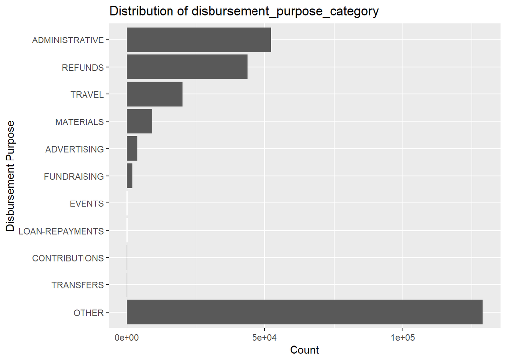

```r
# Visualize some important data columns
ggplot(exp_processed) +
  geom_bar(aes(y=fct_relevel(fct_infreq(disbursement_purpose_category) %>% fct_rev(), "OTHER"))) +
  xlab("Count") +
    ylab("Disbursement Purpose") +
  ggtitle("Distribution of disbursement_purpose_category")
```

As we can see here, the **OTHER** top coding is dominant the dataset, hence it would not provide us lots of interesting information to analyze. But since we have another column which is the **disbursement_description**, we can decode this top code to extract for useful information. Let’s visualize the **disbursement_description** of those marked as **OTHER** first to get an idea of what’s in this column.

```r
exp_processed %>%
  filter(disbursement_purpose_category == 'OTHER') %>%
  group_by(disbursement_description) %>%
  count() %>%
  arrange(desc(n)) %>%
  head(20)
```

```
## # A tibble: 20 x 2
## # Groups:   disbursement_description [20]
##    disbursement_description                 n
##    <chr>                                <int>
##  1 TRAVEL                               23003
##  2 PAYROLL                              13870
##  3 TRANSPORTATION                       12716
##  4 AUTO TRAVEL                           4177
##  5 TRAVEL AGENT FEE                      3768
##  6 TELEPHONE                             3475
##  7 DONATION PROCESSING FEE               3422
##  8 AIR TRAVEL                            3002
##  9 REIMBURSEMENT, SEE BELOW IF ITEMIZED  2628
## 10 MILEAGE                               1927
## 11 CONTRIBUTION REFUND                   1688
## 12 SOFTWARE                              1398
## 13 EVENT/SOUND/STAGING                   1288
## 14 BANKING                               1149
## 15 UTILITIES                             1095
## 16 MERCHANT FEES                         1033
## 17 SHIPPING                               908
## 18 EVENT SUPPLIES                         739
## 19 ADVERTISING                            733
## 20 REIMBURSEMENT - SEE ITEMIZED DETAIL    675
```

Here is the list of existing purpose category:

```r
levels(exp_processed$disbursement_purpose_category)
```

```
##  [1] "ADMINISTRATIVE"  "ADVERTISING"     "CONTRIBUTIONS"   "EVENTS"
##  [5] "FUNDRAISING"     "LOAN-REPAYMENTS" "MATERIALS"       "OTHER"
##  [9] "REFUNDS"         "TRANSFERS"       "TRAVEL"
```

Let’s try to categorize those frequently mentioned descriptions into the purpose category.

```r
# label rows that will be changed before undo top coding
exp_processed <-
  transform(exp_processed, from_other=ifelse(disbursement_purpose_category=='OTHER', TRUE, FALSE))

# Add more factor levels to describe the purpose better
levels(exp_processed$disbursement_purpose_category) <-
  c(levels(exp_processed$disbursement_purpose_category), "BANKING", "CONSULTING")

# Decode disbursement_purpose_category based on the description
exp_processed[grepl("BANK|PROCESS",exp_processed$disbursement_description, ignore.case=T) &
  exp_processed$disbursement_purpose_category == "OTHER", ]$disbursement_purpose_category <- "BANKING"

exp_processed[grepl("CONSULT",exp_processed$disbursement_description, ignore.case=T) &
  exp_processed$disbursement_purpose_category == "OTHER", ]$disbursement_purpose_category <- "CONSULTING"

exp_processed[grepl("SLRY|SALARY|OFFICE|PAYROLL|PYROLL|PHONE|RENT|SOFTWARE|COMPUTER",
        exp_processed$disbursement_description, ignore.case=T) &
    exp_processed$disbursement_purpose_category == "OTHER", ]$disbursement_purpose_category <- "ADMINISTRATIVE"

exp_processed[grepl("MARKET|MARKETING|ADVERTISING", exp_processed$disbursement_description, ignore.case=T) &
    exp_processed$disbursement_purpose_category == "OTHER", ]$disbursement_purpose_category <- "ADVERTISING"

exp_processed[grepl("TRAVEL|TRANSPORT", exp_processed$disbursement_description, ignore.case=T) &
  exp_processed$disbursement_purpose_category == "OTHER", ]$disbursement_purpose_category <- "TRAVEL"

exp_processed[grepl("STAG|STAGING|SHIP", exp_processed$disbursement_description, ignore.case=T) &
  exp_processed$disbursement_purpose_category == "OTHER", ]$disbursement_purpose_category <- "MATERIALS"

exp_processed[grepl("EVENT|CATER|UTIL",exp_processed$disbursement_description, ignore.case=T) &
  exp_processed$disbursement_purpose_category == "OTHER", ]$disbursement_purpose_category <- "EVENTS"

exp_processed[grepl("CONTRIBUTION", exp_processed$disbursement_description, ignore.case=T) &
  exp_processed$disbursement_purpose_category == "OTHER", ]$disbursement_purpose_category <-"CONTRIBUTIONS"

exp_processed[grepl("REFUND|MILEAGE|REIMBURSE", exp_processed$disbursement_description, ignore.case=T) &
  exp_processed$disbursement_purpose_category == "OTHER", ]$disbursement_purpose_category <-"REFUNDS"
```

Here is the distribution after undo the top coding:

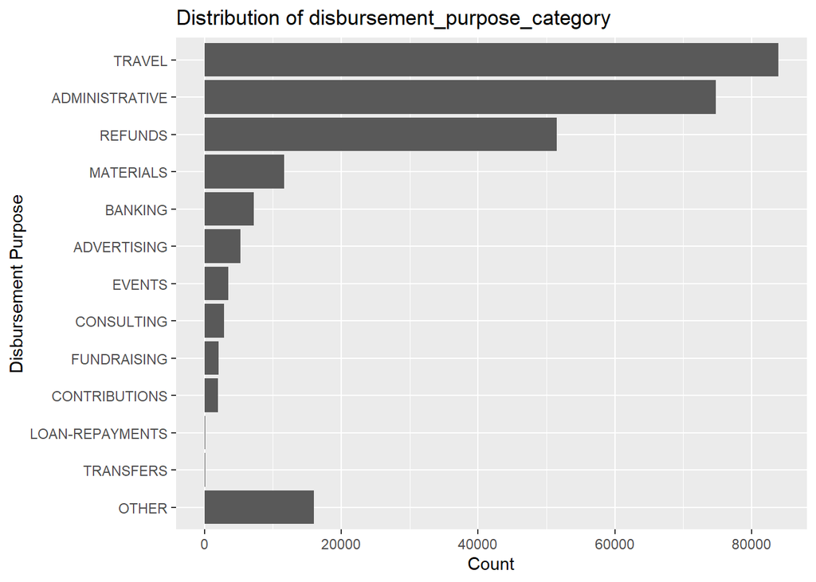

```r
ggplot(exp_processed) +
  geom_bar(aes(y=fct_relevel(fct_infreq(disbursement_purpose_category) %>% fct_rev(), "OTHER"))) +
  xlab("Count") +
    ylab("Disbursement Purpose") +
  ggtitle("Distribution of disbursement_purpose_category")
```

Now the top coding category is less significant than before, and we can perform further analysis on this cleaned data set.

```r
write.csv(exp_processed,"disbursement_processed.csv", row.names = FALSE)
```